# Modelling Peak Electricity Demand in Great Britain [2842 words]

Group-26: Sulixiang Lu, Shiyuan Feng, Yichong Gao

# Introduction

### Task Overview

This report addresses the critical task of modeling future daily peak electricity demand in Great Britain for the National Electricity System Operator (NESO). The primary objective is to develop a reliable linear regression model that can generate realistic simulations of daily peak demand, particularly focusing on high-risk periods of electricity shortfalls. These periods typically occur during winter months due to increased heating and lighting needs, making accurate demand forecasting essential for long-term system planning and security of supply analysis.

### Data Description

Two datasets are provided for analysis:

1. **SCS_demand_modelling.csv**: Contains historical demand data and various explanatory variables such as wind and solar generation capacity factors, temperature, day of the week, month, and year. This dataset focuses on winter periods when demand is highest.
2. **SCS_hourly_temp.csv**: Provides hourly temperature data. The daily peak demand is assumed to occur at 6 p.m.

Head of Demand Modelling Dataset

| X | Date | wind | solar_S | demand_gross | temp | wdayindex | monthindex | year | TO | TE | start_year | DSN |
| --- | --- | --- | --- | --- | --- | --- | --- | --- | --- | --- | --- | --- |
| 1 | 1991-11-01 | 0.764529 | 0 | 44356.5 | 11.529558 | 5 | 10 | 1991 | 12.157059 | 11.365201 | 1991 | 1 |
| 2 | 1991-11-02 | 0.592676 | 0 | 38432.0 | 9.914229 | 6 | 10 | 1991 | 10.359491 | 10.862346 | 1991 | 2 |
| 3 | 1991-11-03 | 0.402806 | 0 | 36807.5 | 4.831514 | 0 | 10 | 1991 | 5.820183 | 8.341264 | 1991 | 3 |
| 4 | 1991-11-04 | 0.655870 | 0 | 48244.5 | 7.006968 | 1 | 10 | 1991 | 7.068754 | 7.705009 | 1991 | 4 |
| 5 | 1991-11-05 | 0.359595 | 0 | 48525.5 | 2.167777 | 2 | 10 | 1991 | 3.493899 | 5.599454 | 1991 | 5 |
| 6 | 1991-11-06 | 0.772210 | 0 | 48845.5 | 8.407002 | 3 | 10 | 1991 | 8.196707 | 6.898080 | 1991 | 6 |

Head of Hourly Temperature Dataset

[output not shown]

### Methodology

- **Data Import and Cleaning**: Ensure correct date formats, remove duplicates, and align hourly temperature data with daily peak demand at 6 p.m.
- **Exploratory Visualizations**: Reveal key patterns in temperature, seasonality, and demand extremes.
- **Feature Engineering**: Create polynomial temperature terms, weekend indicators, and segmented time trends.
- **Model Building**: Construct and iteratively refine several linear regression models.
- **Model Evaluation**: Assess performance using cross-validation, RMSE, MAE, and residual diagnostics.
- **Scenario Analysis**: Explore how peak demand varies under historical weather patterns, providing insights into system sensitivity and planning needs.

### Key Conclusions

The report concludes with recommendations for NESO to utilize the final model for long-term planning and security of supply analysis, while acknowledging the model’s limitations and suggesting areas for future improvement.

# Data description and exploratory analysis

### Data Cleaning

After an initial inspection of data structure and missing values, we confirmed that both datasets were well-aligned and largely complete. There were no missing values in the temperature dataset, and only a few observations in the demand data lacked values for `demand_gross`. These incomplete rows were removed to ensure data quality and integrity for subsequent modelling.

To ensure precise temporal alignment, the `Date` variables in both datasets were converted to R’s `Date class`. The hourly temperature dataset, originally in “DD/MM/YYYY HH:MM” format, was parsed using the `dmy_hm()` function to extract date and hour components. Daily peak demand, defined at 6 p.m., was aligned by filtering the dataset to retain only the 6 p.m. temperature readings, which were then merged with the primary demand dataset.

### Feature Engineering

- A set of new variables was engineered to capture key structural and temporal patterns in the data.
- To account for the nonlinear relationship between temperature and demand, a squared temperature term (`temp_sq`) was introduced.
- The `is_weekend` variable was constructed as a binary factor based on `wdayindex`, allowing for the distinction between weekday and weekend behavior in electricity usage.
- To address structural shifts over time, particularly around 2006—a identified inflection point in demand behavior—segmented linear trend terms (`trend_pre` for years through 2006 and trend_post for subsequent years) were created.
- Additionally, daily average (`temp_avg`), minimum (`temp_min`), and maximum (`temp_max`) temperatures were computed from hourly temperature data.

**To explore key demand drivers and seasonality, several visualisations were constructed.**

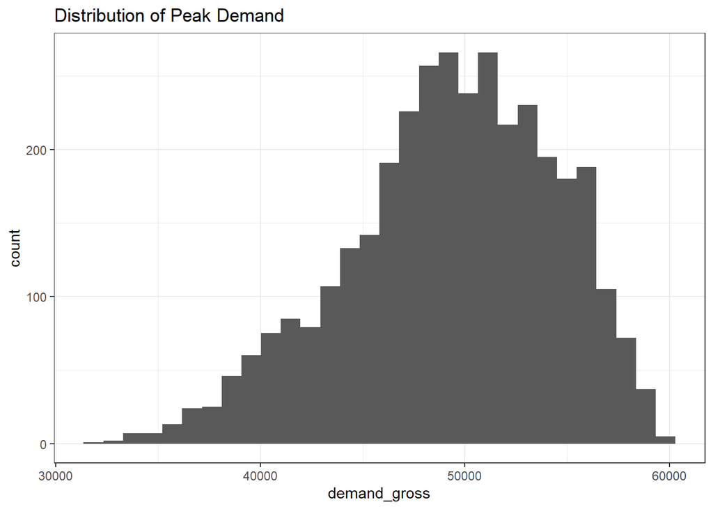

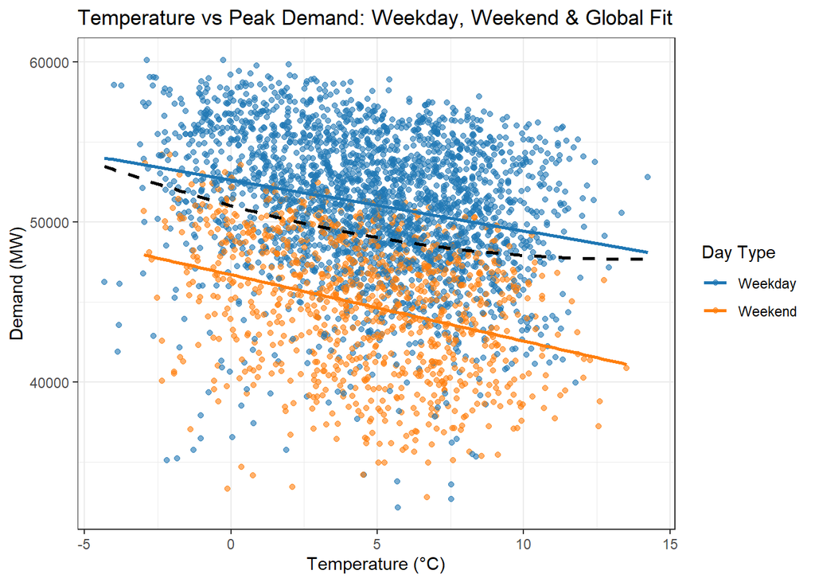

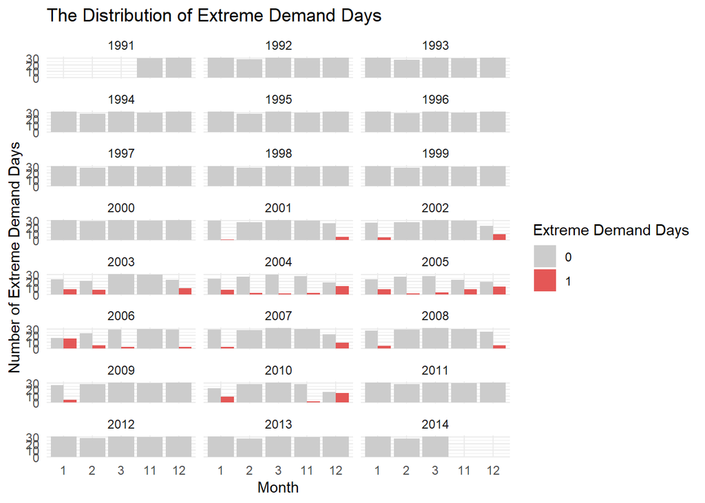

A composite plot overlaying the number of extreme demand days with monthly average temperatures from 2001 to 2010 highlighted the negative correlation between temperature and peak demand likelihood.

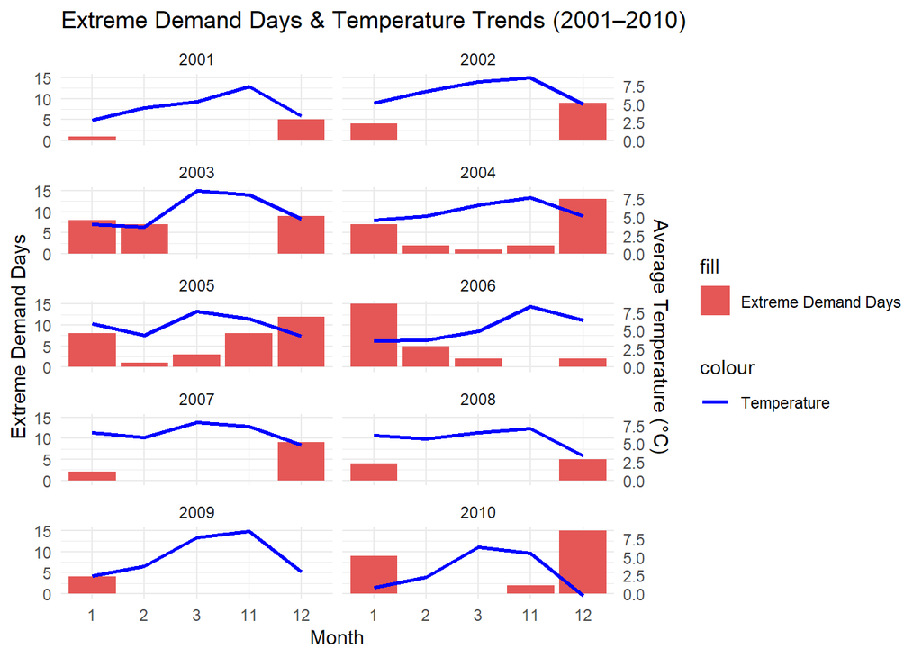

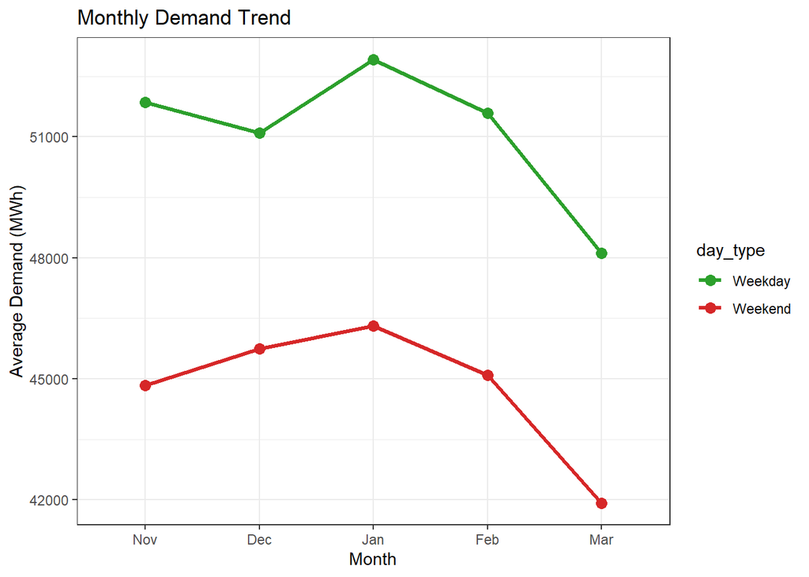

A time-series plot of demand revealed a gradual evolution in peak demand levels, with a discernible structural break around 2006. This inflection likely reflects macro-level shifts such as population dynamics, economic trends, or improved energy efficiency. To account for this temporal non-stationarity, the model incorporated segmented year trend variables (trend_pre and trend_post), enabling the adjustment for historical year effects and enhancing predictive accuracy.

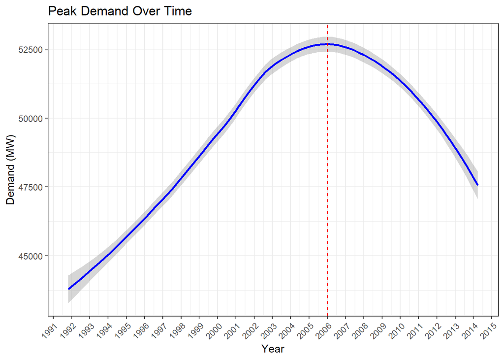

Finally, quantile regression reveals that wind generation has a negative but statistically uncertain impact on peak demand, indicating inconsistent effects across quantiles. In contrast, solar generation demonstrates a weaker but more stable influence.

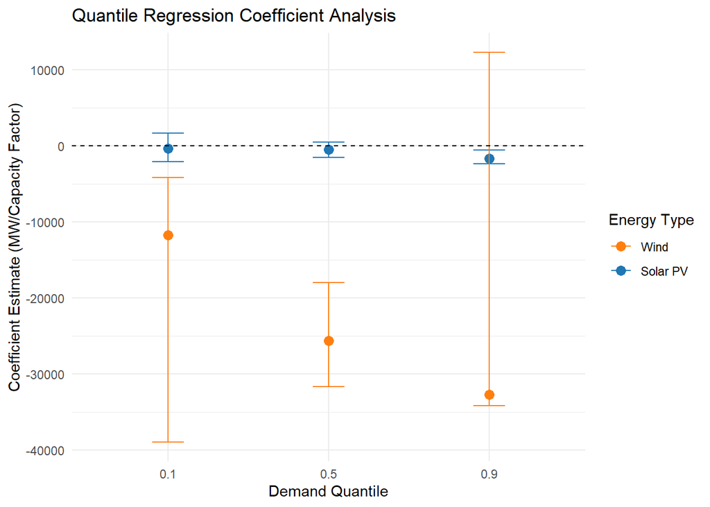

Overall, the exploratory analysis confirmed the central role of temperature—especially during evening peak hours—as well as seasonal and structural temporal effects. These insights informed both feature engineering and model specification, laying the foundation for the development of a transparent and interpretable regression model.

# Model fitting and cross-validation results

## Model Selection and Refinement

### 1. **Choosing Temperature Variables**

To determine the most appropriate temperature variable for modeling, we compared several temperature metrics:

- `temp`: (population-weighted average temperature at 6 p.m.)
- `TO`: (average temperature from 3 p.m. to 6 p.m.)
- `TE`: (average of TO at 6 p.m. and TE at 6 p.m. on the previous day)
- `average temperature`: (daily average temperature)

The comparison involved fitting models with each temperature variable and evaluating their performance using metrics such as R², Adjusted R², MSE, and DS.

The **Model with `TE` and `temp`** performed the best, as confirmed by residual analysis and cross-validation. It showed the lowest MSD and DS score, indicating the strongest fit for the temperature-demand relationship. Additionally, this model had the highest predictive power, with the strongest correlation to demand and the highest adjusted R-squared.

| Model | adj.r.squared | MSE | DS |
| --- | --- | --- | --- |
| TE | 0.077 | 24134399 | 62619.04 |
| Temp | 0.046 | 24952785 | 62735.06 |
| TO | 0.066 | 24435706 | 62662.21 |
| average temperature | 0.052 | 24790407 | 62712.34 |
| TE+Temp | 0.091 | 23750042 | 62563.19 |

### 2. **Polynomial Regression**

From data analysis and graphical visualization, we find that the relationship between demand and temperature has nonlinear characteristics. By establishing the multiple term model:
$$\text{M_multiple}: Y_i = \beta_0 + \beta_1 \mathit{Wind}_i + \beta_2
\mathit{Solar}_i + \beta_3 \mathit{temp}_i + \beta_4
\mathit{temp^2}_i + \varepsilon_i, \qquad \varepsilon_i \sim
\text{Normal}(0, \sigma^2)$$
It is found that the *p-value* for `temp_sq` $= 0.00694 < 0.05$, so we need to consider the higher degree term of temperature. By incorporating quadratic ($temp^2_i$) and cubic ($temp^3_i$) terms of temperature, along with polynomial terms of `TE` ($TE^2_i$, $TE^3_i$), the model achieves better fitting of this complex nonlinear relationship.

Through model evaluation, we find that higher-order polynomials do not significantly improve model performance and may lead to overfitting. Therefore, the appropriate polynomial order is selected so that the model can maintain a balance between the fitting complexity and the generalization ability. However, we can try using *Ridge regression* or *Lasso regression* for regularization, in order to reduce overfitting.

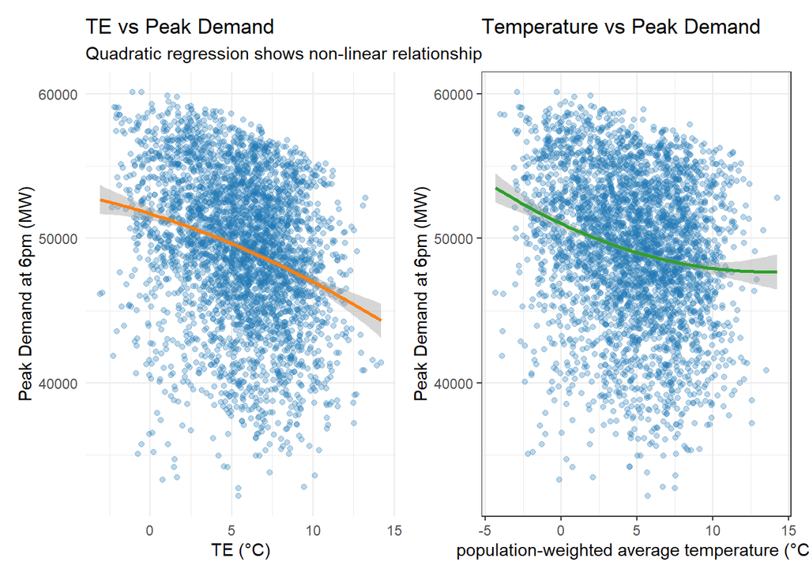

Choosing Temperature Variables

Model Comparison: Regularized vs Traditional Linear Models

| Model | Adj_R2 | MSE |
| --- | --- | --- |
| demand_gross ~ TE^2 + TE | 0.0769 | 24151657 |
| demand_gross ~ temp^2 + temp | 0.0443 | 25005216 |
| demand_gross ~ TE^2 + temp^2 + TE + temp | 0.0878 | 23859690 |
| demand_gross ~ TE^3 + temp^3 + TE^2 + temp^2 + TE + temp | 0.0878 | 23859690 |
| demand_gross ~ TE^4 + temp^4 + TE^3 + temp^3 + TE^2 + temp^2 + | 0.0878 | 23859690 |
| TE + temp | 0.0878 | 23859690 |
| Lasso (TE^3 + temp^3 + TE^2 + tmep^2 + TE + temp) | 0.1025 | 23488612 |
| Ridge (TE^3 + temp^3 + TE^2 + tmep^2 + TE + temp) | 0.1025 | 23489211 |

### 3. **Adding Year as a Variable**

To account for long-term trends in electricity demand, we explored different methods of incorporating the year variable:

Method-1 improved over M0 but didn’t account for the structural break. Through residual analysis and cross-validation. Method-2 shows superiority, but Method-3 has the strongest predictive power. It is recommended to modify the data-set using multiplicative weighting and add segmented trends.

| Model | adj.r.squared | MSE | DS |
| --- | --- | --- | --- |
| Year as constant variable | 0.599 | 10458720 | 59709.92 |
| Year weight | 0.664 | 5091949 | 57205.82 |
| Section trend | 0.762 | 6190692 | 57885.58 |

#### **Baseline Model (M0)**

The baseline model (M0) is a linear regression given by:
$$\text{M0}: Y_i = \beta_0 + \beta_1 \mathit{Wind}_i + \beta_2
\mathit{Solar}_i + \beta_3 \mathit{temp}_i + \beta_4
\mathit{wdayindex}_i + \beta_5 \mathit{monthindex}_i + \varepsilon_i,
\qquad \varepsilon_i \sim \text{Normal}(0, \sigma^2)$$

While M0 provides a starting point, it fails to capture non-linear temperature effects, time trends, and interaction effects that are critical for accurately modeling peak demand.

#### **Model M1**

Model M1 introduces several refinements over M0:

- **Temperature Effects**: Terms for temperature variables (`temp` and `TE`) are added to capture the non-linear relationship between temperature and demand.
- **Time Trends**: Segmented trends for pre-2006 (`trendpre`) and post-2006 (`trendpost`) periods are included to account for structural changes in demand patterns.
- **dummy variable**:

$$\text{M1}: Y_i = \beta_0 + \beta_1 \mathit{Wind}_i + \beta_2
\mathit{Solar}_i + \beta_3 \mathit{temp}_i + \beta_4
\mathit{wdayindex}_i + \beta_5 \mathit{monthindex}_i + \beta_6
\mathit{TE}_i \\
\qquad + \beta_7 \mathit{trend pre}_i + \beta_8 \mathit{trend post}_i +
\beta_{pre} + \varepsilon_i, \qquad \varepsilon_i \sim \text{Normal}(0,
\sigma^2)$$

#### **Model M2 (Final Model)**

Model M2 further refines M1 by:

- **Removing Redundant Variables**: Variables with high p-values (e.g., `temp`, `is_weekend`) are removed to improve model parsimony.
- **Interaction Terms**: Interactions between temperature and time trends, as well as between renewable energy variables and temperature, ect. They are added to capture complex relationships.
- **quadratic and cubic terms**: The inclusion of second- and third-order polynomial terms for both temperature ($temp^2$, $temp^3$) and thermal effectiveness ($TE^2$, $TE^3$) significantly improves the model’s capacity to capture nonlinear dynamics.

$$\text{M2}: Y_i = \beta_0 + \beta_1 \mathit{Wind}_i + \beta_2
\mathit{Solar}_i + \beta_3 \mathit{monthindex}_i + \beta_4
\mathit{wdayindex}_i + \beta_5 \mathit{temp^2}_i + \beta_6
\mathit{temp^3}_i + \beta_7 \mathit{TE}_i + \beta_8 \mathit{TE^3}_i \\
\qquad \qquad + \beta_9 \mathit{trend pre}_i + \beta_{10} \mathit{trend
post}_i + \beta_{pre} + \beta_{11} \mathit{TE:trend post}_i +
\beta_{12} \mathit{TE:trend pre}_i + \beta_{13} \mathit{TE:solar_S}_i \\
+ \beta_{14} \mathit{trend pre:is weekend}_i + \beta_{15} \mathit{trend
post:is weekend}_i + \varepsilon_i, \qquad \varepsilon_i \sim
\text{Normal}(0, \sigma^2)$$

We removed the `I(TE^2)` and `temp` terms. Because they have a strong linear association with the other terms, their corresponding p-values are too large, which leads to their extremely limited influence on the model.

### Why Other Models Were Rejected

**Regularized Regression (Ridge and Lasso)**:

While we tried to apply Ridge regression for regularization to reduce overfitting, the polynomial linear regression ultimately demonstrated superior performance. Based on cross-validation and model evaluation metrics (e.g., adjusted $R^2$ and MSE), the polynomial linear regression showed advantages in both prediction accuracy and generalization capability.

Final Model Comparison: lm() vs Ridge

| Model | Adj_R2 | MSE |
| --- | --- | --- |
| Original lm() final_model | 0.7953 | 5316887 |
| Ridge (TE³ + temp³ + interactions) | 0.7751 | 5885102 |

### Scenario Analysis: Maximum Demand Variation under Historical Weather Conditions

The results showed significant variation in maximum demand across scenarios. The original 2013-14 winter had a maximum demand of **52,453 MW**. Colder winters, like `1993`, were linked to higher peak demands. However, lower average temperatures didn’t always mean higher demand. For example, `2005` had a lower average temperature, but its relatively mild minimum temperatures resulted in lower maximum demand than `1991` and `1993`.

This analysis shows the importance of weather in peak electricity demand. It offers NESO a clearer view of potential demand variations under different weather scenarios, aiding long-term planning and supply security.

Analysis of the Changes in the Maximum Demand during the 2013-14 Winter under Different Historical Weather Conditions

| Scenario | Temperature Metrics Max Demand (MW) | Temperature Metrics Avg Temp (°C) | Temperature Metrics Avg TE (°C) | Temperature Metrics Min Temp (°C) | Temperature Metrics Min TE (°C) | Renewables Metrics Wind Avg | Renewables Metrics Solar Avg | Renewables Metrics Wind Max | Renewables Metrics Solar Max |
| --- | --- | --- | --- | --- | --- | --- | --- | --- | --- |
| Original 2013-14 Winter | 52453.00 | 5.60 | 6.36 | 0.05 | 3.22 | 0.47 | 0.00 | 0.92 | 0.35 |
| winter_1992 | 54264.27 | 4.81 | 5.55 | -2.65 | -0.94 | 0.44 | 0.01 | 0.92 | 0.40 |
| winter_2005 | 54294.06 | 3.85 | 4.62 | -1.43 | -0.49 | 0.37 | 0.00 | 0.90 | 0.31 |
| winter_1991 | 54494.21 | 4.58 | 5.31 | -2.95 | -1.19 | 0.41 | 0.01 | 0.84 | 0.33 |
| winter_1993 | 55075.92 | 4.08 | 4.78 | -2.36 | -0.87 | 0.47 | 0.01 | 0.88 | 0.28 |

## Compare Model

### Model Performance Comparison

To compare the predictive performance and suitability of the proposed models, we computed standard regression metrics for **M0 (Baseline)**, **M1 (Optimized)** and **M2 (Final)**.

The following table summarizes the key performance metrics across the three models:

Model Performance Comparison Table

| Model | Goodness of Fit R² | Goodness of Fit Adjusted R² | Prediction Error RMSE (MW) | Prediction Error MAE (MW) | Prediction Error Extreme Day MAE (MW) |
| --- | --- | --- | --- | --- | --- |
| M0 (Baseline) | 0.466 | 0.464 | 3739.9 | 2960.7 | 5023.7 |
| M1 (Optimized) | 0.781 | 0.780 | 2394.9 | 1512.7 | 1916.8 |
| M2 (Final) | 0.797 | 0.795 | 2307.3 | 1420.2 | 1917.7 |

Note: All error metrics are in megawatts (MW); extreme days are defined as the top 5% of demand values.

### Residual Analysis on Extreme Demand Days

#### Residual Distribution on Extreme Days

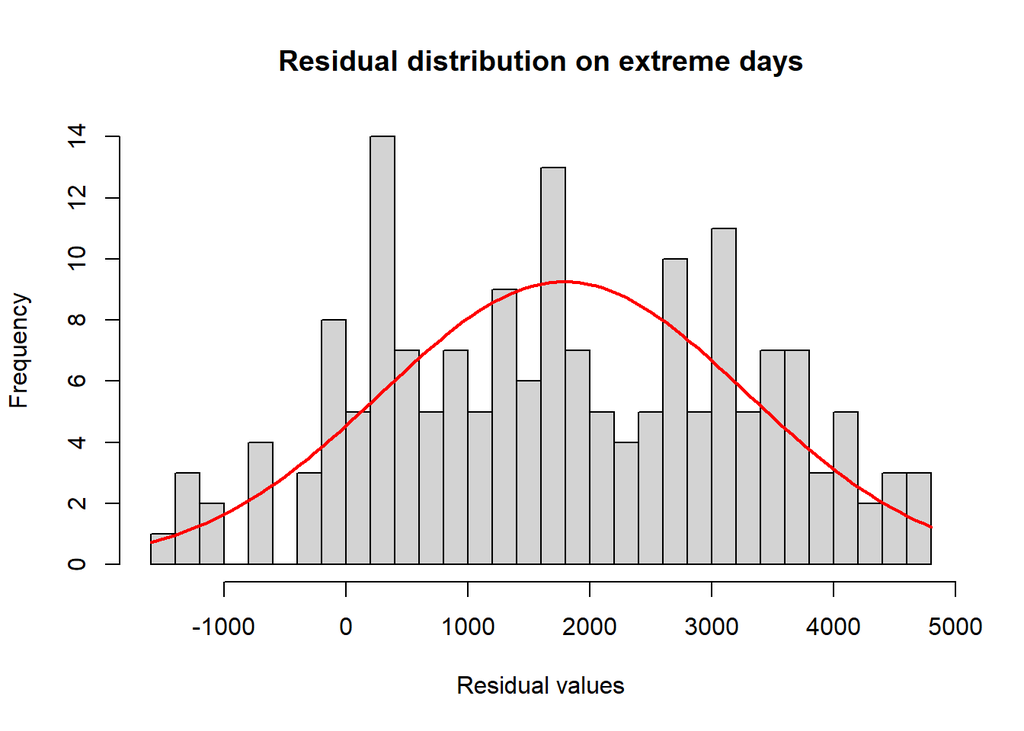

### Residual Diagnostics

Residual diagnostics for the optimized model (M2) were performed to verify linear regression assumptions. The standard diagnostic plots include:

- **Residuals vs Fitted**:shows a slight funnel pattern, indicating mild heteroscedasticity.
- **Q-Q Plot**: reveals deviations from normality in the lower tail and some heavy-tailed behavior, suggesting non-normality in residuals.
- **Scale-Location**: indicates acceptable variance stability overall.
- **Residuals vs Leverage**: highlights a few moderately influential points but no extreme outliers.

These findings suggest that while some assumptions are mildly violated, the model remains robust for forecasting purposes.

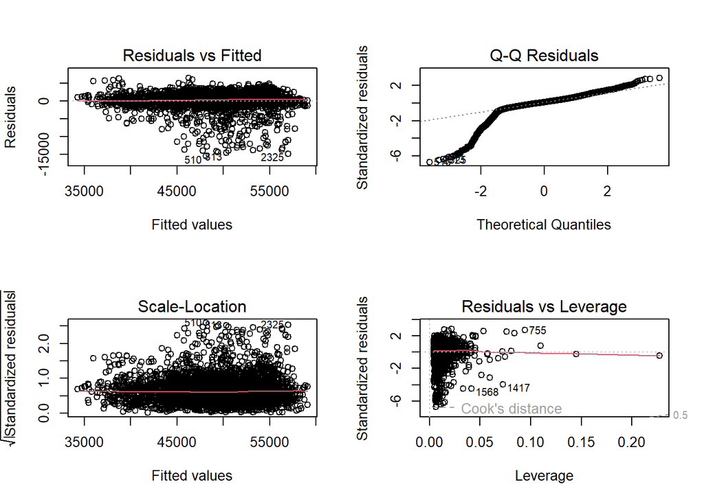

Standard Diagnostic Plots for Model M2

#### Residual Distribution in the Upper Tail

To address NESO’s focus on extreme demand prediction, we assessed the residual behavior for the top 5% of demand days. A focused Q-Q plot was generated after refitting model M2 to this high-demand subset.

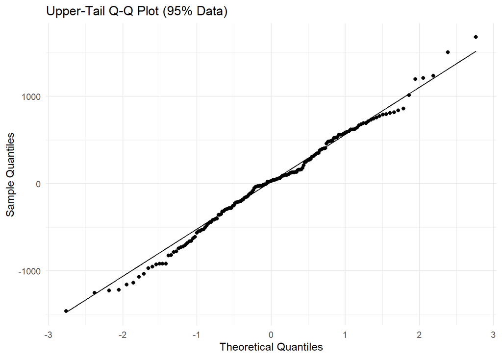

The Q-Q plot for extreme demand days shows residuals closely aligning with normality, with only slight curvature at the extremes. This confirms the model’s error structure is well-behaved for high-demand winter days, supporting reliable extreme-event forecasting.

### Variable Importance Analysis

Standardized Coefficients (Variable Importance)

[output not shown]

Note:  
Effects calculated as coefficients multiplied by predictor SD

#### Key findings from the table:

Top 10 Most Influential Variables in Final Model

| Variable | Estimate | p-value |
| --- | --- | --- |
| solar_S | -39951.855 | 1.28e-17 |
| poly(TE, 3)2 | -18955.779 | 6.15e-06 |
| poly(temp, 2)1 | 18435.989 | 0.00424 |
| poly(temp, 3)3 | 13200.916 | 6.89e-05 |
| poly(temp, 2)2 | 7662.922 | 0.0639 |
| poly(TE, 3)3 | -7049.377 | 0.0357 |
| wdayindexTue | 6871.036 | 7.05e-205 |
| wdayindexWed | 6782.706 | 3.56e-200 |
| wdayindexMon | 6704.426 | 3.9e-196 |
| wdayindexThu | 6576.240 | 8.51e-190 |

Day-of-week variables (wdayindexTue, Wed, etc.) have large positive effects, aligning with working-day peak consumption behavior.

Renewable energy (solar_S) shows a negative coefficient, reflecting reduced demand net of generation.

Interaction terms such as TE:trend_post and solar_S:TE are also significant, indicating that the impact of temperature evolves over time and interacts with renewable input.

## Cross-Validation and Monthly Performance Comparison

### Predicted vs Actual Demand (Visual Check)

To further inspect model behavior, we plotted predicted vs actual values from all models:

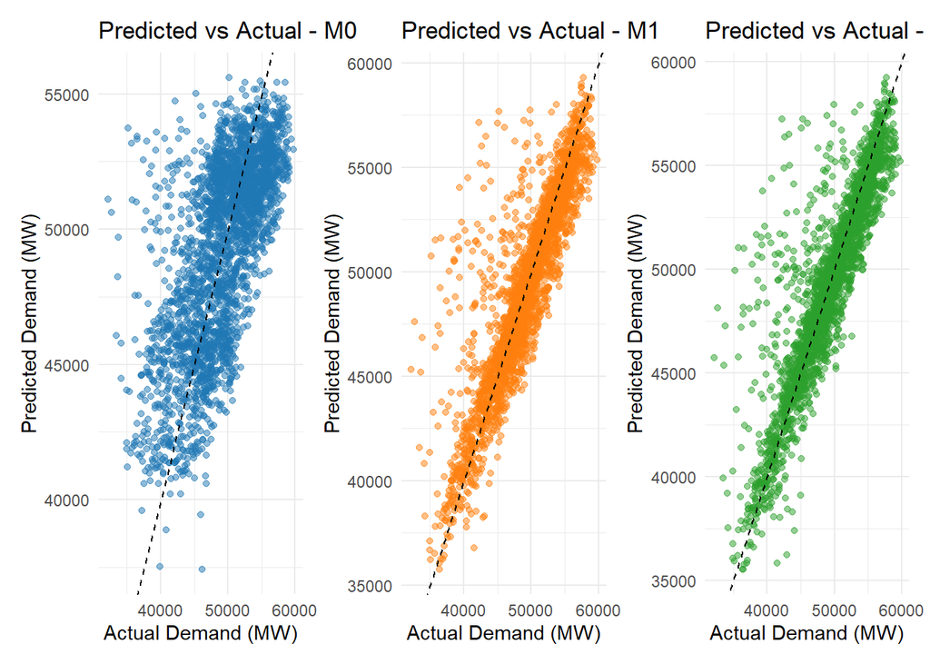

The baseline model (left) shows substantial dispersion and systematic bias, while M1 (center) shows marked improvement. The Final model (right) demonstrates tight clustering along the diagonal, confirming its superior calibration and accuracy.

### Monthly MSE Breakdown

To explore temporal consistency, we calculated monthly MSE values across models:

Monthly MSE Comparison Across Models

| Month | M0 | M1 | Final |
| --- | --- | --- | --- |
| January | 13067173 | 4594782 | 4291844.2 |
| February | 9541239 | 1065641 | 944158.6 |
| March | 10903761 | 2705392 | 2738866.3 |
| November | 8639541 | 1296824 | 924005.3 |
| December | 27447531 | 18353564 | 17393452.0 |

The high accuracy in February and November suggests that these months’ demand patterns are well-captured by the model, possibly due to stable demand trends or effective feature representation. And the significant MSE increase in December may stem from unique seasonal factors, such as holidays or extreme weather, causing demand volatility that the model struggles to predict.

# Conslusion

A dependable and understandable framework for forecasting the daily peak demand for electricity in Great Britain is provided by the final regression model (M2). Undoubtedly, this model is subject to several limitations.The heteroscedasticity, especially in the top tail of the demand distribution, is suggested by residual diagnostics, which may compromise the accuracy of forecasts in severe circumstances. Furthermore, socioeconomic or policy-related factors that can become more significant over time, such economic activity or the adoption of electric vehicles, are not included in the model. More adaptable models (such as additive or non-parametric techniques) could better handle complicated interactions without sacrificing interpretability, even though polynomial terms aid in capturing non-linearities.

M2 can be a useful tool for NESO’s long-term planning and supply security assessments because of its simplicity and performance. As the energy landscape changes, we advise updating the model frequently to take into account new information and reevaluate presumptions. In the future, NESO might think about expanding this approach to solve variance difficulties with **generalized least squares (GLS)** or investigate **machine learning** techniques to capture higher-order interactions. The model can continue to offer helpful recommendations for planning risk reduction and infrastructure investment with diligent observation and improvement.

# Code Appendix

Include here all the code used in your analysis. Ensure that the code is well-commented so it is easy to follow and reuse.

```r
# ---------------------------
# Data Import and Initial Inspection
# ---------------------------
# Load required packages
library(ggplot2)
library(patchwork)
library(tidyverse)
library(lubridate)
library(lme4)
library(knitr)
library(dplyr)
library(kableExtra)
library(car)         # For calculating Variance Inflation Factor (VIF)
library(quantreg)    # Quantile regression
library(caret)       # Cross-validation
library(glmnet)      # Regularized regression
library(broom)       # Tidy up model outputs
theme_set(theme_bw())

# Load data sets
demand_modelling <- read.csv("SCS_demand_modelling.csv", stringsAsFactors = FALSE) %>%
  mutate(Date = as.Date(Date))   # Ensure the date format is correct

hourly_temp <- read.csv("SCS_hourly_temp.csv", stringsAsFactors = FALSE)

# Check structure
str(demand_modelling)
summary(demand_modelling)
print(head(demand_modelling))
str(hourly_temp)
summary(hourly_temp)

print(min(demand_modelling$temp))


# ---------------------------
# Data Cleaning
# ---------------------------
# Check date format in the main dataset
class(demand_modelling$Date)
head(demand_modelling$Date)

# Check date format in the temperature dataset
class(hourly_temp$Date)
head(hourly_temp$Date)

# Convert hourly_temp$Date from "DD/MM/YYYY HH:MM" character to Date class
hourly_temp <- hourly_temp %>%
  mutate(
    DateTime = dmy_hm(Date),        # First parse as datetime with day-month-year-hour-minute
    Date = as.Date(DateTime),       # Then extract just the date portion
    Hour = hour(DateTime)
  ) %>%
  select(Date, Hour, temp_hour = temp)


# 1. Check for missing values
colSums(is.na(demand_modelling))
colSums(is.na(hourly_temp))   # All 0s indicate no missing values

demand_clean <- demand_modelling %>%
  # Remove rows with completely missing values
  filter(!is.na(demand_gross))


# 2. Check for duplicate records
duplicates <- duplicated(demand_modelling)
if(sum(duplicates) > 0) {
  print(paste("Duplicates found, removing them. Number of duplicates:", sum(duplicates)))
  demand_clean <- demand_clean[!duplicates, ]
} else {
  print("No duplicate records found")
}


# View summary of cleaned data
summary(demand_clean)


# ---------------------------
# Data Inspection
# ---------------------------
# Check variable types
#glimpse(demand_modelling)

# Display head of demand_modelling dataset
demand_head <- head(demand_modelling)
kable(demand_head, caption = "Head of Demand Modelling Dataset") %>%
  kable_styling(bootstrap_options = "striped", full_width = FALSE)

# Display head of hourly_temp dataset
hourly_temp_head <- head(hourly_temp)
kable(hourly_temp_head, caption = "Head of Hourly Temperature Dataset") %>%
  kable_styling(bootstrap_options = "striped", full_width = FALSE)

# Temperature-demand scatter plot (merging hourly temperature with daily demand)
# Shows temperature impact on demand and weekend effect
merged_temp <- hourly_temp %>%
  filter(Hour == 18) %>%  # Align with daily peak hour
  inner_join(demand_modelling, by = "Date")


# Calendar plot of extreme demand days
# Identify peak periods (e.g., cold spells)
extreme_days <- demand_modelling %>%
  mutate(
    date = as.Date(Date),
    is_extreme = as.integer(demand_gross > quantile(demand_gross, 0.95, na.rm = TRUE)),
    month = month(date)
  )
extreme_days$is_extreme <- as.factor(extreme_days$is_extreme)


# Filter for years 2001–2010
extreme_days <- demand_modelling %>%
  mutate(
    date = as.Date(Date),
    year = year(date),
    month = month(date),
    is_extreme = as.integer(demand_gross > quantile(demand_gross, 0.95, na.rm = TRUE))
  ) %>%
  filter(year >= 2001 & year <= 2010) %>%
  group_by(year, month) %>%
  summarise(
    extreme_count = sum(is_extreme),     # Number of extreme demand days per month
    avg_temp = mean(TE, na.rm = TRUE),    # Average monthly temperature(TE)
    .groups = "drop"
  ) %>%
  ungroup()
extreme_count <- extreme_days[["extreme_count"]]
avg_temp <- extreme_days[["avg_temp"]]

# Overlay temperature data to indicate extreme weather events
# Bars = number of extreme demand days, line = temperature trend
plot_temperature_demand <- function(data, x_var, y_var, day_type_var, title = NULL, x_label = NULL, y_label = NULL) {
  ggplot(data, aes(x = {{ x_var }}, y = {{ y_var }})) +
    geom_point(aes(color = ifelse({{ day_type_var }} %in% c(0, 6), "Weekend", "Weekday")), alpha = 0.6) +
    geom_smooth(aes(color = ifelse({{ day_type_var }} %in% c(0, 6), "Weekend", "Weekday")),
                method = "lm", formula = 'y ~ x', se = FALSE) +
    geom_smooth(method = "lm", formula = y ~ poly(x, 2), se = FALSE, color = "black", linetype = "dashed", linewidth = 1) +  # Global fit
    scale_color_manual(values = c("Weekday" = "#1F77B4", "Weekend" = "#FF7F0E")) +
    labs(
      title = title,
      x = x_label,
      y = y_label,
      color = "Day Type"
    )
}



# Monthly demand trend plot
# Shows seasonal variation and weekend effect
monthly_demand <- demand_modelling %>%
  mutate(
    # Ensure monthindex is in the range 0–11
    monthindex = pmax(0, pmin(11, monthindex)),

    # Create month factor (1–12 mapped to Jan–Dec)
    month = factor(
      monthindex + 1,
      levels = 1:12,
      labels = month.abb
    ),
    month = factor(month,
                   levels = c("Nov", "Dec", "Jan", "Feb", "Mar"),
                   ordered = TRUE),

    # Weekday/Weekend classification
    day_type = ifelse(wdayindex %in% c(0, 6), "Weekend", "Weekday")
  ) %>%
  group_by(month, day_type) %>%
  summarise(
    avg_demand = mean(demand_gross, na.rm = TRUE),
    .groups = "drop"
  )


# Quantile Regression Analysis of Renewable Energy
library(quantreg)

# Build quantile regression model
rq_model <- rq(
  demand_gross ~ wind + solar_S,
  data = demand_modelling,
  tau = c(0.1, 0.5, 0.9)  # Analyze 10th, 50th, 90th percentiles
)

# ---------------------------
# Feature Engineering
# ---------------------------
# Convert categorical variables into factors (dummy variables),
# fix factor order and labels, and add new response variables.
demand_features <- demand_clean %>%
  mutate(
    # Month (only winter months)
    monthindex = factor(monthindex,
                        levels = c(0, 1, 2, 10, 11),
                        labels = c("Jan", "Feb", "Mar", "Nov", "Dec")),
    # Day of the week
    wdayindex = factor(wdayindex,
                       levels = c(0, 1, 2, 3, 4, 5, 6),
                       labels = c("Sun", "Mon", "Tue", "Wed", "Thu", "Fri", "Sat")),
```

```r
    # Weekend indicator (based on corrected wdayindex)
    is_weekend = ifelse(wdayindex %in% c("Mon", "Tue", "Wed", "Thu", "Fri"), 0, 1),
    is_weekend = as.factor(is_weekend),

    # Year effects
    trend_pre = ifelse(year <= 2006, year - 2006, 0),
    trend_post = ifelse(year > 2006, year - 2006, 0)
  )

# Check month levels
levels(demand_features$monthindex)
# Check weekday levels
levels(demand_features$wdayindex)


# Polynomial temperature terms
demand_modelling <- demand_modelling %>%
  mutate(temp_sq = temp^2)

# Fit a model with a nonlinear (quadratic) term
model_nonlinear <- lm(demand_gross ~ temp + temp_sq + wind + solar_S, data = demand_modelling)
summary(model_nonlinear)
# Since p-value for temp_sq = 0.00694 < 0.05 ---> indicates nonlinearity exists, so we include temp^2


# Daily min/max temperature (using hourly_temp.csv)
temp_daily <- hourly_temp %>%
  group_by(Date) %>%
  summarise(
    temp_avg = mean(temp_hour),     # Daily average temperature
    temp_min = min(temp_hour),      # Daily minimum temperature
    temp_max = max(temp_hour),      # Daily maximum temperature
  )

# Merge with main dataset
demand_features <- demand_features %>%
  left_join(temp_daily, by = "Date")


# ---------------------------
# Building the model
# ---------------------------

#---Choosing temperature variable(temp,TO,TE,average temperature)-----------
# TE and demand_gross scatter plot + non-linear fitting
te_plot <- demand_features %>%
  ggplot(aes(x = TE, y = demand_gross)) +
  geom_point(alpha = 0.3, color = "#1f77b4") +
  geom_smooth(
    method = "lm",
    formula = y ~ poly(x, 2),  # Polynoimal Fitting
    color = "#ff7f0e",
    se = TRUE
  ) +
  labs(
    title = "TE vs Peak Demand",
    subtitle = "Quadratic regression shows non-linear relationship",
    x = "TE (°C)",
    y = "Peak Demand at 6pm (MW)"
  ) +
  theme_minimal()

# Compare temp and TE
temp_plot <- demand_features %>%
  ggplot(aes(x = temp, y = demand_gross)) +
  geom_point(alpha = 0.3, color = "#1f77b4") +
  geom_smooth(
    method = "lm",
    formula = y ~ poly(x, 2),
    color = "#2ca02c",
    se = TRUE
  ) +
  labs(
    title = "Temperature vs Peak Demand",
    x = "population-weighted average temperature (°C)",
    y = "Peak Demand at 6pm (MW)"
  )


# MODEL 1: Using TE only
m_te <- lm(demand_gross ~ poly(TE, 2), data = demand_features)

# MODEL 2: Using temp only
m_temp <- lm(demand_gross ~ poly(temp, 2), data = demand_features)

# MODEL3: Using TO Only
m_to <- lm(demand_gross ~ poly(TO, 2) , data = demand_features)

# MODEL4: Using temp_avg only
m_avg <- lm(demand_gross ~ poly(temp_avg, 2), data = demand_features)

# MODEL 5: TE and temp
m_both <- lm(demand_gross ~ poly(TE, 2) + poly(temp, 2), data = demand_features)


# Compute every model MSE and DS
model_comparison_temp <- list(
  "TE" = m_te,
  "Temp" = m_temp,
  "TO" = m_to,
  "average temperature" = m_avg,
  "TE+Temp" = m_both
) %>%
  purrr::map_dfr(function(model) {
    # Extracting predicting value, residuals, sigma
    fitted <- predict(model)
    residuals <- residuals(model)
    sigma <- sigma(model)
    n <- nobs(model)

    # Compute MSE and DS
    MSE <- mean(residuals^2)
    DS <- sum((residuals / sigma)^2) + 2 * n * log(sigma)

    # Return result
    glance(model) %>%
      select(adj.r.squared) %>%
      mutate(MSE = MSE, DS = DS)
  }, .id = "Model")

# Display Result
knitr::kable(model_comparison_temp, digits = 3)


#---Regularization (Ridge and Lasso Regression)---
# Create polynomial features manually for control
demand_features <- demand_features %>%
  mutate(
    TE_sq = TE^2,
    TE_cu = TE^3,
    temp_sq = temp^2,
    temp_cu = temp^3,
    TE_qu = TE^4,
    temp_qu = temp^4
  )

# Define predictor matrix (X) and response vector (y)
X <- demand_features %>%
  select(TE, TE_sq, TE_cu, TE_qu, temp, temp_sq, temp_cu, temp_cu, wind, solar_S) %>%
  as.matrix()

y <- demand_features$demand_gross

# Ridge regression (alpha = 0)
cv_ridge <- cv.glmnet(X, y, alpha = 0, standardize = TRUE)

# Lasso regression (alpha = 1)
cv_lasso <- cv.glmnet(X, y, alpha = 1, standardize = TRUE)

# Best lambda values
best_lambda_ridge <- cv_ridge$lambda.min
best_lambda_lasso <- cv_lasso$lambda.min

# Extract coefficients at best lambda
coef_ridge <- coef(cv_ridge, s = "lambda.min")
coef_lasso <- coef(cv_lasso, s = "lambda.min")

# Predictions using best lambda models
pred_ridge <- predict(cv_ridge, newx = X, s = "lambda.min")
pred_lasso <- predict(cv_lasso, newx = X, s = "lambda.min")

# R-squared function
rsq <- function(actual, predicted) {
  1 - sum((actual - predicted)^2) / sum((actual - mean(actual))^2)
}

m_te    <- lm(demand_gross ~ TE^2 + TE, data = demand_features)
m_temp  <- lm(demand_gross ~ temp^2 +temp, data = demand_features)
m_both  <- lm(demand_gross ~ TE^2 + temp^2 + TE + temp, data = demand_features)
m_te_2    <- lm(demand_gross ~ TE^3 + TE^2 + TE, data = demand_features)
m_temp_2  <- lm(demand_gross ~ temp^3 + temp^2 +temp, data = demand_features)
m_both_2  <- lm(demand_gross ~ TE^3 + temp^3 + TE^2 + temp^2 + TE + temp, data = demand_features)

# Helper function to get MSE
get_lm_metrics <- function(model) {
  fitted <- predict(model)
  residuals <- model$residuals
  MSE <- mean(residuals^2)
  data.frame(
    Model = deparse(model$call$formula),
    Adj_R2 = summary(model)$adj.r.squared,
    MSE = MSE
  )
}

# Collect metrics
lm_results <- bind_rows(
  get_lm_metrics(m_te),
  get_lm_metrics(m_temp),
  get_lm_metrics(m_both),
  get_lm_metrics(m_te_2),
  get_lm_metrics(m_temp_2),
  get_lm_metrics(m_both_2)
)

# Calculate metrics
ridge_result <- data.frame(
  Model = "Ridge (TE^3 + temp^3 + TE^2 + tmep^2 + TE + temp)",
  Adj_R2 = rsq(y, pred_ridge),
  MSE = mean((y - pred_ridge)^2)
)

lasso_result <- data.frame(
  Model = "Lasso (TE^3 + temp^3 + TE^2 + tmep^2 + TE + temp)",
  Adj_R2 = rsq(y, pred_lasso),
  MSE = mean((y - pred_lasso)^2)
)

# Combine all results
all_results <- bind_rows(
  lm_results,
  ridge_result,
  lasso_result
)

# Show nicely
kable(all_results, digits = 4, caption = "Model Comparison: Regularized vs Traditional Linear Models")
```

```r
#-----------Adding year as a variable-------------------
## Model 1: Set year as constant variable
m_year <- lm(demand_gross ~ wind + solar_S + temp + wdayindex + monthindex +
               year, data = demand_features)

## Model 2: add Weight for years
# Compute base year (1991) average demand
base_year <- 1991
base_demand <- mean(demand_features$demand_gross[demand_features$year == base_year])

# Compute each year gamma_t
year_effect <- demand_features %>%
  group_by(year) %>%
  summarise(mean_demand = mean(demand_gross)) %>%
  mutate(gamma_t = mean_demand / base_demand)

# Combine and return original data
demand_adjusted <- demand_features %>%
  left_join(year_effect, by = "year") %>%
  mutate(demand_scaled = demand_gross / gamma_t)

m_weight <- lm(
  demand_scaled ~ wind + solar_S + temp + wdayindex + monthindex,
  data = demand_adjusted
)


## Model 3: Using multiple section trends
m_trend <- lm(
  demand_gross ~ wind + solar_S + temp + wdayindex + monthindex + trend_pre + trend_post,
  data = demand_features
)


# Compute each model MSE and DS
model_comparison_year <- list(
  "Year as constant variable" = m_year,
  "Year weight" = m_weight,
  "Section trend" = m_trend
) %>%
  purrr::map_dfr(function(model) {
    fitted <- predict(model)
    residuals <- residuals(model)
    sigma <- sigma(model)
    n <- nobs(model)

    # Compute MSE and DS
    MSE <- mean(residuals^2)
    DS <- sum((residuals / sigma)^2) + 2 * n * log(sigma)

    # Return result
    glance(model) %>%
      select(adj.r.squared) %>%
      mutate(MSE = MSE, DS = DS)
  }, .id = "Model")

# Display result
knitr::kable(model_comparison_year, digits = 3)

# Construct based model M0
model_M0 <- lm(demand_gross ~ 1 + wind + solar_S + temp + wdayindex + monthindex, data = demand_features)
summary(model_M0)

# Model M1: Construct year, temperature, is_weekend
M1_formula <- demand_gross ~ 1 +
  wind + solar_S +            # Reusable resources
  wdayindex +                 # week day type effect
  monthindex +                # monthly type effect
  temp + TE +                 # temperature effect
  I(year > 2006)+             # based demand after 2006
  trend_pre + trend_post +    # cross validation trend
  is_weekend                  # weekly effect

model_M1 <- lm(M1_formula, data = demand_features)
summary(model_M1)

#----> remove 'is_week_end' because it has strong collinearity with 'wdayindex'. The model output result is NA
M1_optimized <- update(model_M1, . ~ .  - is_weekend, data = demand_features)
summary(M1_optimized)


# Add interaction terms
M2_formula <- demand_gross ~ 1 +
  wind + solar_S +            # Renewable energy
  wdayindex +                 # Main effect of day of the week
  monthindex +                # Main effect of month
  temp + I(temp^2) + I(temp^3) + TE + I(TE^2) + I(TE^3) +  # Temperature effect
  I(year > 2006) +            # Change in baseline demand after 2006 (intercept)
  trend_pre + trend_post +    # Orthogonalized segmented trends
  TE:trend_post +             # Interaction between temperature and time trend (post)
  TE:trend_pre +
  TE:monthindex +             # Interaction between temperature and time period
  TE:wind +                   # Interaction between renewable energy and temperature
  TE:solar_S +
  trend_pre:is_weekend +      # Interaction between time trend and periodic effect
  trend_post:is_weekend +
  trend_post:monthindex


model_M2 <- lm(M2_formula, data = demand_features)
summary(model_M2)

#-----> Remove independent variables with p-value > 0.05
M2_optimized <- update(model_M2, . ~ .  - I(TE^2) -temp - TE:monthindex - TE:wind - trend_post:monthindex, data = demand_features)
summary(M2_optimized)


# Compare models
# Define a generic function to calculate model performance metrics
calculate_model_metrics <- function(model, data, demand_var = "demand_gross") {
  # Compute basic residuals
  residuals <- residuals(model)

  # Compute standard performance metrics
  metrics <- list(
    R2 = summary(model)$r.squared %>% round(3),
    Adj_R2 = summary(model)$adj.r.squared %>% round(3),
    RMSE = sqrt(mean(residuals^2)) %>% round(1),
    MAE = mean(abs(residuals)) %>% round(1)
  )

  # Compute metrics for extreme days (95th percentile)
  extreme_threshold <- quantile(data[[demand_var]], 0.95, na.rm = TRUE)
  extreme_days <- data[[demand_var]] >= extreme_threshold
  metrics$Extreme_MAE <- mean(abs(residuals[extreme_days])) %>% round(1)

  return(metrics)
}

# Calculate metrics for each model
metrics_M0 <- calculate_model_metrics(model_M0, demand_features)
metrics_M1 <- calculate_model_metrics(M1_optimized, demand_features)
metrics_M2 <- calculate_model_metrics(M2_optimized, demand_features)

# 1. Build comparison table
performance_table <- bind_rows(
  metrics_M0 %>% as_tibble() %>% add_column(Model = "M0 (Baseline)", .before = 1),
  metrics_M1 %>% as_tibble() %>% add_column(Model = "M1 (Optimized)", .before = 1),
  metrics_M2 %>% as_tibble() %>% add_column(Model = "M2 (Final)", .before = 1)
) %>%
  select(Model, R2, Adj_R2, RMSE, MAE, Extreme_MAE)

print(ncol(performance_table))
# Generate styled performance table
kable(performance_table,
      align = c("l", rep("c", 5)),
      col.names = c("Model", "R²", "Adjusted R²", "RMSE (MW)", "MAE (MW)", "Extreme Day MAE (MW)"),
      caption = "Model Performance Comparison Table") %>%
  kable_styling(
    bootstrap_options = c("striped", "hover", "condensed"),
    full_width = FALSE,
    position = "center"
  ) %>%
  add_header_above(c(" " = 1, "Goodness of Fit" = 2, "Prediction Error" = 3)) %>%
  footnote(
    general = "Note: All error metrics are in megawatts (MW); extreme days are defined as the top 5% of demand values.",
    general_title = ""
  )

# Extreme Day Residual Distribution Plot
# Calculate residuals
residuals <- residuals(model_M2)

# RMSE
RMSE <- sqrt(mean(residuals^2))

# MAE
MAE <- mean(abs(residuals))

# Extreme Day Forecasting Error (MAE of 95th Percentile Day)
high_demand_threshold <- quantile(demand_adjusted$demand_gross, 0.95)
extreme_days <- demand_adjusted$demand_gross >= high_demand_threshold
MAE_extreme <- mean(abs(residuals[extreme_days]))
```

```r
# Upper-tail residuals
## Select data where `demand_gross` is greater than the 95th percentile.
demand_high <- demand_features %>%
  filter(demand_gross > quantile(demand_gross, 0.95)) %>%
  droplevels()

demand_high <- demand_high %>%
  mutate(is_weekend = as.numeric(is_weekend))

# Refit the M2 formula on the filtered data.
model_M2_95 <- lm(M2_formula, data = demand_high)

# Extract residuals.
residuals_M2_95 <- residuals(model_M2_95)


# 3. Variable importance (standardized coefficients).
std_coef <- data.frame(
  variable = names(coef(model_M2)),
  effect = coef(model_M2) * apply(model.matrix(model_M2), 2, sd)
) %>% arrange(desc(abs(effect)))

# Create formatted table
std_coef %>%
  rename(`Standardized Effect` = effect) %>%
  kable(
    caption = "Standardized Coefficients (Variable Importance)",
    align = c("l", "r"),
    digits = 3,
    row.names = FALSE  # Key adjustment: Disable row name output.
  ) %>%
  kable_styling(
    bootstrap_options = c("striped", "hover"),
    full_width = FALSE,
    position = "center"
  ) %>%
  column_spec(2, background = "#f7f7f7") %>%
  footnote(
    general = "Effects calculated as coefficients multiplied by predictor SD",
    general_title = "Note:"
  )


# 4. Extreme value prediction ability verification (95th percentile day).
extreme_days <- demand_features %>%
  filter(demand_gross > quantile(demand_gross, 0.95))

extreme_pred <- predict(model_M2, newdata = extreme_days)
extreme_mape <- mean(abs(extreme_days$demand_gross - extreme_pred)/extreme_days$demand_gross)


#---Contribute best model---
# use Ridge (TE³ + temp³) on Final Model
ridge_formula <- ~ 1 +
  wind + solar_S +
  wdayindex +
  monthindex +
  I(temp^2) + I(temp^3) + TE + I(TE^3) +
  I(year > 2006) +
  trend_pre + trend_post +

  TE:trend_post +
  TE:trend_pre +
  TE:solar_S +
  trend_pre:is_weekend +
  trend_post:is_weekend

# X matrix with all predictors (excluding intercept)
X_ridge <- model.matrix(ridge_formula, data = demand_features)[, -1]

# Response vector
y_ridge <- demand_features$demand_gross

# Cross-validated Ridge
cv_ridge_full <- cv.glmnet(X_ridge, y_ridge, alpha = 0, standardize = TRUE)

# Final Ridge model at best lambda
ridge_final <- glmnet(X_ridge, y_ridge, alpha = 0, lambda = cv_ridge_full$lambda.min)

# View best lambda
cat("Best lambda for final Ridge model:", cv_ridge_full$lambda.min, "\n")

# Predict on training data
pred_ridge_full <- predict(ridge_final, newx = X_ridge)

# R² and MSE
rsq <- function(actual, predicted) {
  1 - sum((actual - predicted)^2) / sum((actual - mean(actual))^2)
}
ridge_rsq <- rsq(y_ridge, pred_ridge_full)
ridge_mse <- mean((y_ridge - pred_ridge_full)^2)

cat("Final Ridge Model R²:", round(ridge_rsq, 4), "\n")
cat("Final Ridge Model MSE:", round(ridge_mse, 2), "\n")


final_formula <- demand_gross ~ 1 +
  wind + solar_S +
  wdayindex +
  monthindex +
  poly(temp,2) + poly(temp,3) + TE + poly(TE,3) +
  I(year > 2006)+
  trend_pre + trend_post +

  TE:trend_post +
  TE:trend_pre +
  TE:solar_S +
  trend_pre:is_weekend +
  trend_post:is_weekend


final_model <- lm(final_formula, data = demand_features)
summary(final_model)

final_lm_mse <- mean((demand_features$demand_gross - predict(final_model))^2)
final_lm_r2 <- summary(final_model)$adj.r.squared

comparison <- tibble::tibble(
  Model = c("Original lm() final_model", "Ridge (TE³ + temp³ + interactions)"),
  Adj_R2 = c(final_lm_r2, ridge_rsq),
  MSE = c(final_lm_mse, ridge_mse)
)

knitr::kable(comparison, digits = 4, caption = "Final Model Comparison: lm() vs Ridge")
#---> choose final linear regression model


# ---------------------------
# Analyze the changes in the maximum annual demand during the winter of 2013-14 under different historical weather conditions
# ---------------------------
## 1. Data Preparation and Weather Scenario Construction
# Define the baseline winter (2013-14)
base_winter <- demand_features %>%
  filter(
    Date >= as.Date("2013-11-01"),
    Date <= as.Date("2014-03-31")
  ) %>%
  select(-temp, -TE, -wind, -solar_S)  # Remove weather variable

# Determine the date range for the winter of 2013-14 (assuming winter is from November to March of the following year).
base_dates <- seq(as.Date("2013-11-01"), as.Date("2014-03-31"), by = "day")

# Extract the baseline data (excluding weather variables).
base_data <- demand_modelling %>%
  filter(Date %in% base_dates) %>%
  select(-temp, -wind, -solar_S)  # Remove weather variables, which will be replaced with historical weather data later.

# Extract historical weather data.
historical_winters <- list(
  winter_1991 = seq(as.Date("1991-11-01"), as.Date("1992-03-31"), by = "day"),
  winter_1992 = seq(as.Date("1992-11-01"), as.Date("1993-03-31"), by = "day"),
  winter_1993 = seq(as.Date("1993-11-01"), as.Date("1994-03-31"), by = "day"),
  winter_2005 = seq(as.Date("2005-11-01"), as.Date("2006-03-31"), by = "day")
)

# Extract weather variables for each winter (retain alignment with DSN).
weather_data <- lapply(historical_winters, function(dates) {
  demand_features %>%
    filter(Date %in% dates) %>%
    mutate(DSN = DSN) %>%  # Use the original DSN for alignment
    select(DSN, temp, TE, wind, solar_S)
})

# Construct a weather scenario dataset.
scenarios <- lapply(weather_data, function(weather) {
  base_winter %>%
    left_join(weather, by = "DSN") %>%  # Align strictly by DSN.
    filter(!is.na(temp))  # Remove dates without weather data.
})

## 2. Demand Forecasting and Extreme Value Analysis
# Predict demand for each scenario.
predict_scenario <- function(scenario_data) {
  scenario_data %>%
    mutate(
      pred_demand = predict(final_model, newdata = .),
      # Calculate temperature-related metrics.
      temp_bin = cut(temp, breaks = c(-Inf, 0, 5, 10, Inf)),
      TE_squared = TE^2
    )
}

scenario_results <- lapply(scenarios, predict_scenario)

# Extract the maximum annual demand.
max_demands <- sapply(scenario_results, function(df) {
  max(df$pred_demand, na.rm = TRUE)
})

# Construct a results table.
results_table <- data.frame(
  Scenario = names(historical_winters),
  MaxDemand_MW = max_demands,
  AvgTemp = sapply(scenario_results, function(df) mean(df$temp, na.rm = TRUE)),
  AvgTE = sapply(scenario_results, function(df) mean(df$TE, na.rm = TRUE)),
  MinTemp = sapply(scenario_results, function(df) min(df$temp, na.rm = TRUE)),
  MinTE = sapply(scenario_results, function(df) min(df$TE, na.rm = TRUE)),
  Wind_Avg = sapply(scenario_results, function(df) mean(df$wind, na.rm = TRUE)),
  Solar_Avg = sapply(scenario_results, function(df) mean(df$solar_S, na.rm = TRUE)),
  Wind_Max = sapply(scenario_results, function(df) max(df$wind, na.rm = TRUE)),
  Solar_Max = sapply(scenario_results, function(df) max(df$solar_S, na.rm = TRUE))
)
```

```r
# Assume the actual data for the original 2013-14 winter.
original_2013 <- data.frame(
  Scenario = "Original 2013-14 Winter",
  MaxDemand_MW = max(demand_features$demand_gross[demand_features$Date %in% base_dates]),
  AvgTemp = mean(demand_features$temp[demand_features$Date %in% base_dates]),
  AvgTE = mean(demand_features$TE[demand_features$Date %in% base_dates], na.rm = TRUE),
  MinTemp = min(demand_features$temp[demand_features$Date %in% base_dates]),
  MinTE = min(demand_features$TE[demand_features$Date %in% base_dates], na.rm = TRUE),
  Wind_Avg = mean(demand_features$wind[demand_features$Date %in% base_dates]),
  Solar_Avg = mean(demand_features$solar_S[demand_features$Date %in% base_dates]),
  Wind_Max = max(demand_features$wind[demand_features$Date %in% base_dates]),
  Solar_Max = max(demand_features$solar_S[demand_features$Date %in% base_dates])
)

# Merge the original data into the results table.
final_table <- rbind(original_2013, results_table) %>%
  arrange(MaxDemand_MW)  # Sort by demand in descending order.

## 3. Output visualization.
# Use `kable` to output an aesthetically pleasing table.
final_table %>%
  kable(
    format = "html",
    align = "c",
    digits = 2,
    col.names = c("Scenario", "Max Demand (MW)", "Avg Temp (°C)", "Avg TE",
                  "Min Temp (°C)", "Min TE", "Wind Avg", "Solar Avg",
                  "Wind Max", "Solar Max"),
    caption = "Analysis of the Changes in the Maximum Demand during the 2013-14 Winter under Different Historical Weather Conditions析",
    row.names = FALSE  # Key Fix: Disable the display of the row number column.
  ) %>%
  kable_styling(
    bootstrap_options = c("striped", "hover", "condensed"),
    full_width = FALSE,
    font_size = 12
  ) %>%
  add_header_above(
    c(" " = 1,                # The first column (Scenario) is not grouped.
      "Temperature Metrics" = 5,  # Temperature-related columns (Avg Temp, Avg TE, Min Temp, Min TE).
      "Renewables Metrics" = 4   # Renewable energy columns (Wind Avg, Solar Avg, Wind Max, Solar Max).）
    )
  ) %>%
  row_spec(which(final_table$Scenario == "Original 2013-14 Winter"),
           bold = TRUE, color = "white", background = "#2c3e50")

# Extract the number of all scenarios.
all_scenarios <- bind_rows(scenario_results, .id = "Scenario")


# ---------------------------
# Cross-validation: Evaluate by splitting data by month
# ---------------------------
set.seed(12345)
train_indices <- createDataPartition(demand_features$demand_gross, p = 0.8, list = FALSE)
train_data <- demand_features[train_indices, ]
test_data <- demand_features[-train_indices, ]

# Grouped cross-validation by month

# Evaluate model performance by month (supports multiple models)
# Wrap the prediction function
model_predict <- function(model, newdata) {
  pred <- predict(model, newdata = newdata)
  return(data.frame(
    actual = newdata$demand_gross,
    predicted = pred,
    month = newdata$monthindex
  ))
}


# Predictions for all models
pred_m0 <- model_predict(model_M0, demand_features) %>% mutate(model = "M0")
pred_m1 <- model_predict(M1_optimized, demand_features) %>% mutate(model = "M1")
pred_final <- model_predict(final_model, demand_features) %>% mutate(model = "Final")

# Merge all predictions
pred_all <- bind_rows(pred_m0, pred_m1, pred_final)

# Calculate monthly MSE
monthly_mse <- pred_all %>%
  group_by(model, month) %>%
  summarise(
    mse = mean((actual - predicted)^2),
    .groups = "drop"
  )


# Model prediction function
lm_prediction <- function(data, model, newdata) {
  if (model == "M0") {
    fit <- lm(demand_gross ~ wind + solar_S + temp + wdayindex + monthindex, data = data)
  } else if (model == "M1") {
    fit <- model_M1 <- lm(M1_formula, data = data)
  } else if (model == "Final") {
    fit <- lm(final_formula, data = data)
  } else {
    stop("Unknown model type.")
  }

  # Predictions and intervals
  pred <- predict(fit, newdata, interval = "prediction")
  result <- data.frame(
    predicted.mean = pred[, "fit"],
    predicted.sd = (pred[, "upr"] - pred[, "lwr"]) / (2 * qt(0.975, df = fit$df.residual)),
    predicted.lwr = pred[, "lwr"],
    predicted.upr = pred[, "upr"]
  )

  return(result)
}


# Cross-validation function
kfold_validate <- function(data, model_type, k = 10) {
  folds <- caret::createFolds(factor(data$monthindex), k = k, list = TRUE)

  map_dfr(1:k, function(i) {
    test_idx <- folds[[i]]
    train_set <- data[-test_idx, ]
    test_set <- data[test_idx, ]

    tryCatch({
      pred <- lm_prediction(train_set, model_type, test_set)
      cbind(test_set, pred, fold = i)
    }, error = function(e) NULL)
  })
}

# Model evaluation function
compute_scores <- function(pred_df) {
  pred_df %>%
    mutate(
      demand_gross = as.numeric(demand_gross),
      pred_mean = as.numeric(predicted.mean),
      pred_sd = as.numeric(predicted.sd),
      MSE = (demand_gross - pred_mean)^2,
      DS = ifelse(is.na(pred_sd), NA,
                  ((demand_gross - pred_mean)/pred_sd)^2 + 2 * log(pred_sd))
    ) %>%
    group_by(model, fold) %>%
    summarise(
      MSE = mean(MSE, na.rm = TRUE),
      DS = mean(DS, na.rm = TRUE),
      .groups = "drop"
    )
}

# Run cross-validation and evaluate
# Perform cross-validation
cv_results <- map_dfr(c("M0", "M1", "Final"), ~{
  results <- tryCatch(
    kfold_validate(train_data, model_type = .x, k = 10),
    error = function(e) NULL
  )
  if (!is.null(results)) mutate(results, model = .x)
})

# Evaluation calculation
model_scores <- compute_scores(cv_results)

# Summarize evaluations
final_scores <- model_scores %>%
  group_by(model) %>%
  summarise(
    MSE_mean = mean(MSE),
    MSE_se = sd(MSE) / sqrt(n()),
    DS_mean = mean(DS),
    DS_se = sd(DS) / sqrt(n()),
    .groups = "drop"
  )

# Output as a table
final_table <- final_scores %>%
  transmute(
    Model = model,
    MSE = sprintf("%.1f ± %.1f", MSE_mean, MSE_se),
    DS = sprintf("%.1f ± %.1f", DS_mean, DS_se)
  )

final_table %>%
  kbl(
    format = "html", # Choose "html" or "latex" based on the output type
    caption = "Cross-validation Performance Comparison (Mean ± Standard Error)",
    col.names = c("Model", "MSE (Mean ± SE)", "Dawid-Sebastiani Score"),
    align = c("l", "c", "c")  # Column alignment
  ) %>%
  kable_styling(
    bootstrap_options = c("striped", "hover", "condensed"),
    full_width = FALSE,
    font_size = 13,
    position = "center"
  ) %>%
  add_header_above(c(" " = 1, "Performance Metrics" = 2)) %>%  # Add grouped table headers
  column_spec(1, bold = TRUE, width = "6em") %>%  # Bold the model column
  column_spec(2:3, width = "10em") %>%  # Width of the metric columns
  row_spec(which.min(final_scores$MSE_mean),  # Highlight the model with the lowest MSE
           bold = TRUE,
           color = "white",
           background = "#2c3e50"
  ) %>%
  footnote(
    general = "Explanation of evaluation metrics:",
    number = c(
      "MSE = Mean Squared Error (the smaller the better)",
      "DS = Dawid-Sebastiani score (the smaller the better)"
    ),
    footnote_as_chunk = TRUE
  )
```

```r
# Plot predictions vs. actual values
plot_pred_vs_actual <- function(df, model_name, color) {
  df %>%
    filter(model == model_name) %>%
    ggplot(aes(x = demand_gross, y = predicted.mean)) +
    geom_point(alpha = 0.5, color = color) +
    geom_abline(slope = 1, intercept = 0, linetype = "dashed") +
    labs(
      title = paste("Predicted vs Actual -", model_name),
      x = "Actual Demand (MW)",
      y = "Predicted Demand (MW)"
    ) +
    theme_minimal()
}


# PLOT GRAPH
p_m0 <- plot_pred_vs_actual(cv_results, "M0", "#1f77b4")
p_m1 <- plot_pred_vs_actual(cv_results, "M1", "#ff7f0e")
p_final <- plot_pred_vs_actual(cv_results, "Final", "#2ca02c")


monthly_mse_table <- monthly_mse %>%
  pivot_wider(names_from = model, values_from = mse) %>%
  mutate(
    Month = month.name[month],  # First, create a column for month names
    Month = factor(Month, levels = month.name)  # Convert to an ordered factor
  ) %>%
  select(Month, M0, M1, Final) %>%
  arrange(Month)  # Sort by factor order

# Add explicit formatting parameters (HTML or LaTeX)
monthly_mse_table %>%
  kbl(
    format = "html",  # Choose "html" or "latex" based on the output type
    digits = 1,
    caption = "Monthly MSE Comparison Across Models",
    col.names = c("Month", "M0", "M1", "Final")
  ) %>%
  kable_styling(
    bootstrap_options = c("striped", "hover"),
    full_width = FALSE
  )
```